# German_Bank_Loan_Default_Prediction

## Objective

This data set contains historical data of the customers who have taken loans from a German bank and the bank is facing issues with loan defaulters. The bank intends to build a machine learning model to predict whether the customer will default or not based on historical data

### Data Dictionary

- checking_balance - Amount of money available in account of customers
- months_loan_duration - Duration since loan taken
- credit_history - credit history of each customers
- purpose - Purpose why loan has been taken
- amount - Amount of loan taken
- savings_balance - Balance in account
- employment_duration - Duration of employment
- percent_of_income - Percentage of monthly income
- years_at_residence - Duration of current residence
- age - Age of customer
- other_credit - Any other credits taken
- housing- Type of housing, rent or own
- existing_loans_count - Existing count of loans
- job - Job type
- dependents - Any dependents on customer
- phone - Having phone or not
- default - Default status (Target column)

### Import necessary libraries

```python
import pandas as pd
import numpy as np
import matplotlib.pyplot as plt
import seaborn as sns
import warnings
import random
import sklearn

from sklearn.model_selection import train_test_split, GridSearchCV
from sklearn.linear_model import LogisticRegression
from sklearn.discriminant_analysis import LinearDiscriminantAnalysis
from sklearn.metrics import confusion_matrix,classification_report, \
                            roc_auc_score,accuracy_score,roc_curve,precision_recall_curve

from sklearn.ensemble import RandomForestClassifier, GradientBoostingClassifier
from sklearn.svm import SVC
import xgboost as xgb



sns.set_theme(style="whitegrid")
warnings.filterwarnings("ignore")
```

### Check the Versions

```python
'''
Check the versions of pandas, numpy and sklearn
If they are not recent version please update them using the following command

command - !pip install --upgrade <libraryname>
'''
print(f"Pandas version : {pd.__version__}")
print(f"Numpy version : {np.__version__}")
print(f"Sklearn version : {sklearn.__version__}")
```

```
Pandas version : 1.4.4
Numpy version : 1.24.3
Sklearn version : 1.2.2
```

#### Read the dataset

```python
# Function to read the csv data and provide general information about the data.
def read_csv_file(path):
    df = pd.read_csv(path)
    # Prints the shape of the dataset
    print(f"\nThe shape of the dataset : {df.shape}")

    # Prints the number of null values in the each of the columns
    print(f"\nThe number of null values in the each of the columns : \n{df.isnull().sum()}")

    # Prints the total number of null values
    print(f"\nThe total number of null values in the dataset : {df.isnull().sum().sum()}")

    # Prints the total number of duplicate rows
    print(f"\nThe total number of duplicate rows : {df.duplicated().sum()}")

    return df
dataset_name = 'credit.csv' # enter the name of the dataset here
df = read_csv_file(dataset_name)
df.head()
```

```
The shape of the dataset : (1000, 17)

The number of null values in the each of the columns :
checking_balance        0
months_loan_duration    0
credit_history          0
purpose                 0
amount                  0
savings_balance         0
employment_duration     0
percent_of_income       0
years_at_residence      0
age                     0
other_credit            0
housing                 0
existing_loans_count    0
job                     0
dependents              0
phone                   0
default                 0
dtype: int64

The total number of null values in the dataset : 0

The total number of duplicate rows : 0
```

|  | checking_balance | months_loan_duration | credit_history | purpose | amount | savings_balance | employment_duration | percent_of_income | years_at_residence | age | other_credit | housing | existing_loans_count | job | dependents | phone | default |
| --- | --- | --- | --- | --- | --- | --- | --- | --- | --- | --- | --- | --- | --- | --- | --- | --- | --- |
| 0 | < 0 DM | 6 | critical | furniture/appliances | 1169 | unknown | > 7 years | 4 | 4 | 67 | none | own | 2 | skilled | 1 | yes | no |
| 1 | 1 - 200 DM | 48 | good | furniture/appliances | 5951 | < 100 DM | 1 - 4 years | 2 | 2 | 22 | none | own | 1 | skilled | 1 | no | yes |
| 2 | unknown | 12 | critical | education | 2096 | < 100 DM | 4 - 7 years | 2 | 3 | 49 | none | own | 1 | unskilled | 2 | no | no |
| 3 | < 0 DM | 42 | good | furniture/appliances | 7882 | < 100 DM | 4 - 7 years | 2 | 4 | 45 | none | other | 1 | skilled | 2 | no | no |
| 4 | < 0 DM | 24 | poor | car | 4870 | < 100 DM | 1 - 4 years | 3 | 4 | 53 | none | other | 2 | skilled | 2 | no | yes |

### Exploratory Data Analysis

```python
# Check the basic information about the dataset such as column datatypes and non null columns
df.info()
```

```
<class 'pandas.core.frame.DataFrame'>
RangeIndex: 1000 entries, 0 to 999
Data columns (total 17 columns):
 #   Column                Non-Null Count  Dtype
---  ------                --------------  -----
 0   checking_balance      1000 non-null   object
 1   months_loan_duration  1000 non-null   int64
 2   credit_history        1000 non-null   object
 3   purpose               1000 non-null   object
 4   amount                1000 non-null   int64
 5   savings_balance       1000 non-null   object
 6   employment_duration   1000 non-null   object
 7   percent_of_income     1000 non-null   int64
 8   years_at_residence    1000 non-null   int64
 9   age                   1000 non-null   int64
 10  other_credit          1000 non-null   object
 11  housing               1000 non-null   object
 12  existing_loans_count  1000 non-null   int64
 13  job                   1000 non-null   object
 14  dependents            1000 non-null   int64
 15  phone                 1000 non-null   object
 16  default               1000 non-null   object
dtypes: int64(7), object(10)
memory usage: 132.9+ KB
```

```python
# Seperate numeric and object columns
num_cols = df.describe().columns.tolist()
obj_cols = df.select_dtypes(include=['object', 'bool']).columns.tolist()
print(f"Number of numeric columns : {len(num_cols)}")
print(f"Numeric columns :\n{num_cols}")
print()
print(f"Number of object columns : {len(obj_cols)}")
print(f"Object columns :\n{obj_cols}")
```

```
Number of numeric columns : 7
Numeric columns :
['months_loan_duration', 'amount', 'percent_of_income', 'years_at_residence', 'age', 'existing_loans_count', 'dependents']

Number of object columns : 10
Object columns :
['checking_balance', 'credit_history', 'purpose', 'savings_balance', 'employment_duration', 'other_credit', 'housing', 'job', 'phone', 'default']
```

```python
# Check the target variable distribution
df['default'].value_counts(normalize=True)*100
```

```
no     70.0
yes    30.0
Name: default, dtype: float64
```

```python
# Check the summary statistics
df.describe().T
```

|  | count | mean | std | min | 25% | 50% | 75% | max |
| --- | --- | --- | --- | --- | --- | --- | --- | --- |
| months_loan_duration | 1000.0 | 20.903 | 12.058814 | 4.0 | 12.0 | 18.0 | 24.00 | 72.0 |
| amount | 1000.0 | 3271.258 | 2822.736876 | 250.0 | 1365.5 | 2319.5 | 3972.25 | 18424.0 |
| percent_of_income | 1000.0 | 2.973 | 1.118715 | 1.0 | 2.0 | 3.0 | 4.00 | 4.0 |
| years_at_residence | 1000.0 | 2.845 | 1.103718 | 1.0 | 2.0 | 3.0 | 4.00 | 4.0 |
| age | 1000.0 | 35.546 | 11.375469 | 19.0 | 27.0 | 33.0 | 42.00 | 75.0 |
| existing_loans_count | 1000.0 | 1.407 | 0.577654 | 1.0 | 1.0 | 1.0 | 2.00 | 4.0 |
| dependents | 1000.0 | 1.155 | 0.362086 | 1.0 | 1.0 | 1.0 | 1.00 | 2.0 |

#### Counts of categorical variables

```
unknown       394
< 0 DM        274
1 - 200 DM    269
> 200 DM       63
Name: checking_balance, dtype: int64

good         530
critical     293
poor          88
very good     49
perfect       40
Name: credit_history, dtype: int64

furniture/appliances    473
car                     337
business                 97
education                59
renovations              22
car0                     12
Name: purpose, dtype: int64

< 100 DM         603
unknown          183
100 - 500 DM     103
500 - 1000 DM     63
> 1000 DM         48
Name: savings_balance, dtype: int64

1 - 4 years    339
> 7 years      253
4 - 7 years    174
< 1 year       172
unemployed      62
Name: employment_duration, dtype: int64

none     814
bank     139
store     47
Name: other_credit, dtype: int64

own      713
rent     179
other    108
Name: housing, dtype: int64

skilled       630
unskilled     200
management    148
unemployed     22
Name: job, dtype: int64

no     596
yes    404
Name: phone, dtype: int64

no     700
yes    300
Name: default, dtype: int64
```

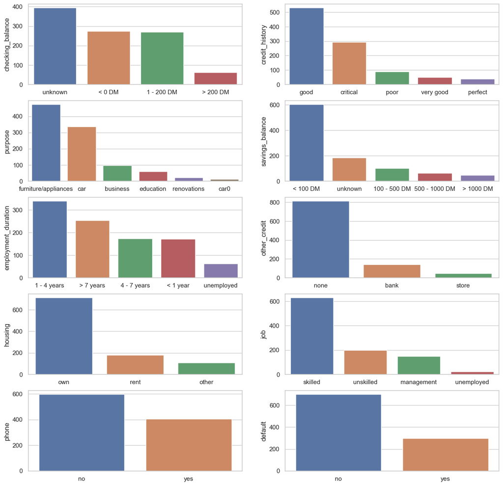

```python
plt.figure(figsize=(15,15))
for index in range(len(obj_cols)):
    plt.subplot(5,2,index+1)
    names = df[obj_cols[index]].value_counts().index
    values = df[obj_cols[index]].value_counts() # unique values in each column
    sns.barplot(x = names, y = values)
    print(values)
    print()
plt.show()
```

#### Proportions of categorical variables

```python
for col in obj_cols:
    values = df[col].value_counts(normalize=True)*100 # check the proportions
    print(values)
    print()
```

```
unknown       39.4
< 0 DM        27.4
1 - 200 DM    26.9
> 200 DM       6.3
Name: checking_balance, dtype: float64

good         53.0
critical     29.3
poor          8.8
very good     4.9
perfect       4.0
Name: credit_history, dtype: float64

furniture/appliances    47.3
car                     33.7
business                 9.7
education                5.9
renovations              2.2
car0                     1.2
Name: purpose, dtype: float64

< 100 DM         60.3
unknown          18.3
100 - 500 DM     10.3
500 - 1000 DM     6.3
> 1000 DM         4.8
Name: savings_balance, dtype: float64

1 - 4 years    33.9
> 7 years      25.3
4 - 7 years    17.4
< 1 year       17.2
unemployed      6.2
Name: employment_duration, dtype: float64

none     81.4
bank     13.9
store     4.7
Name: other_credit, dtype: float64

own      71.3
rent     17.9
other    10.8
Name: housing, dtype: float64

skilled       63.0
unskilled     20.0
management    14.8
unemployed     2.2
Name: job, dtype: float64

no     59.6
yes    40.4
Name: phone, dtype: float64

no     70.0
yes    30.0
Name: default, dtype: float64
```

#### Pairplot

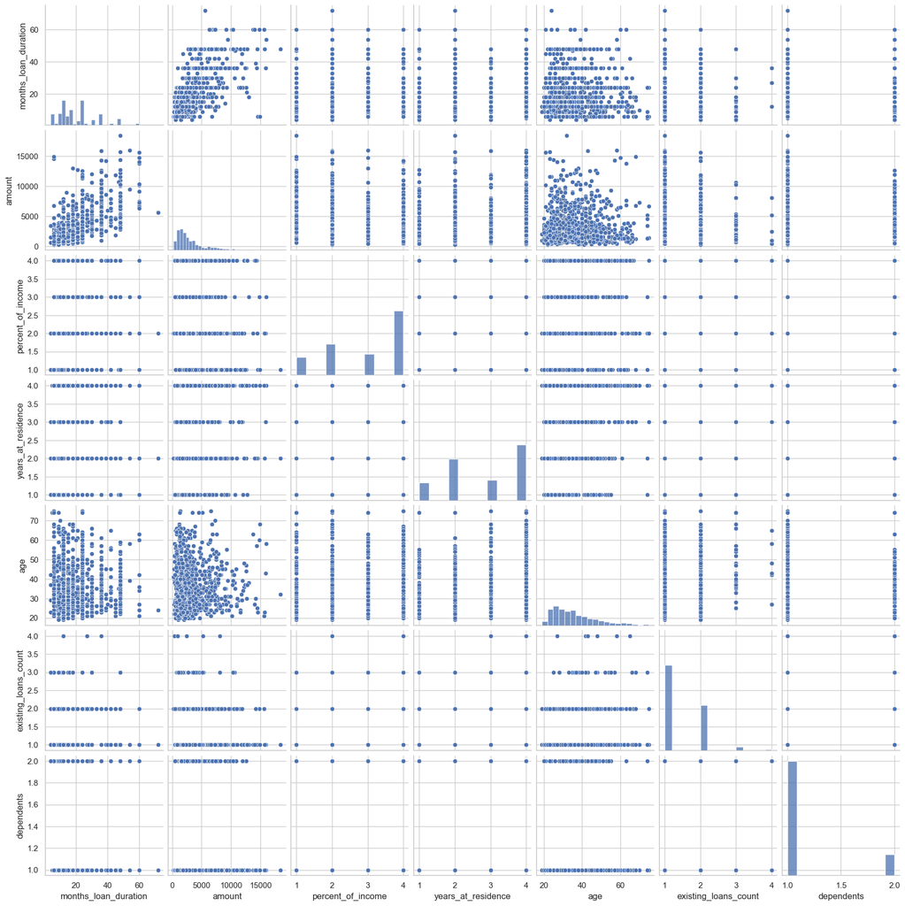

```python
# Pairplot to identify the relations between the variables
sns.pairplot(data = df)
plt.show()
```

#### Correlation matrix

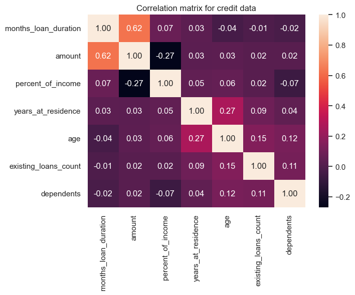

```python
plt.figure(figsize = (7,5))
sns.heatmap(df.corr(), annot = True, fmt=".2f")
plt.title("Correlation matrix for credit data")
plt.show()
```

#### Analyze the defaulters based on the categorical columns

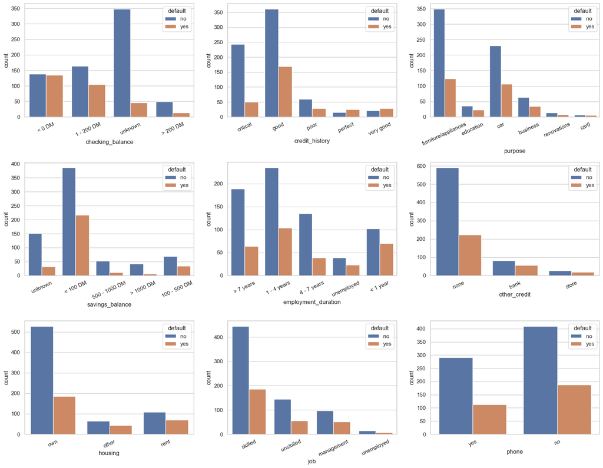

```python
plt.figure(figsize=(20,15))
for index in range(len(obj_cols)):
    column = obj_cols[index]
    if column != 'default':
        plt.subplot(3,3,index+1)
        sns.countplot(x = column, data = df, hue = 'default')
        plt.xticks(rotation = 25)

plt.subplots_adjust(left=0.1,
                    bottom=0.1,
                    right=0.9,
                    top=0.9,
                    wspace=0.2,
                    hspace=0.4)
plt.show()
```

Findings :

- `checking_balance` <0DM have more defaulters compared to other categories. So the customers who have less `checking_balance` tends to default.
- `credit_history` doesn't give a good idea about the defaulters as the customers whose `credit_history` is good has more defaulters than the other categories.
- `purpose` furniture/appliances have more defaulters.
- `employment_duration` 1-4 years have more defaulters.
- `savings_balance` <100DM have more defaulters.
- Similary we can find which category have more defaulters and the bank can have a check before providing the loan.

#### Analyze the defaulters based on the numeric columns

```python
# Fitering only the defaulters from the entire data for the analysis
defualters_df = df[df['default'] == 'yes']
defualters_df.describe().T
```

|  | count | mean | std | min | 25% | 50% | 75% | max |
| --- | --- | --- | --- | --- | --- | --- | --- | --- |
| months_loan_duration | 300.0 | 24.860000 | 13.282639 | 6.0 | 12.0 | 24.0 | 36.0 | 72.0 |
| amount | 300.0 | 3938.126667 | 3535.818955 | 433.0 | 1352.5 | 2574.5 | 5141.5 | 18424.0 |
| percent_of_income | 300.0 | 3.096667 | 1.088395 | 1.0 | 2.0 | 4.0 | 4.0 | 4.0 |
| years_at_residence | 300.0 | 2.850000 | 1.094605 | 1.0 | 2.0 | 3.0 | 4.0 | 4.0 |
| age | 300.0 | 33.963333 | 11.222379 | 19.0 | 25.0 | 31.0 | 40.0 | 74.0 |
| existing_loans_count | 300.0 | 1.366667 | 0.559702 | 1.0 | 1.0 | 1.0 | 2.0 | 4.0 |
| dependents | 300.0 | 1.153333 | 0.360911 | 1.0 | 1.0 | 1.0 | 1.0 | 2.0 |

Findings :

- The average `months_loan_duration` of the defaulters is 24.8.
- The average loan `amount` of the defaulters is 3938 and median is 2574.5.

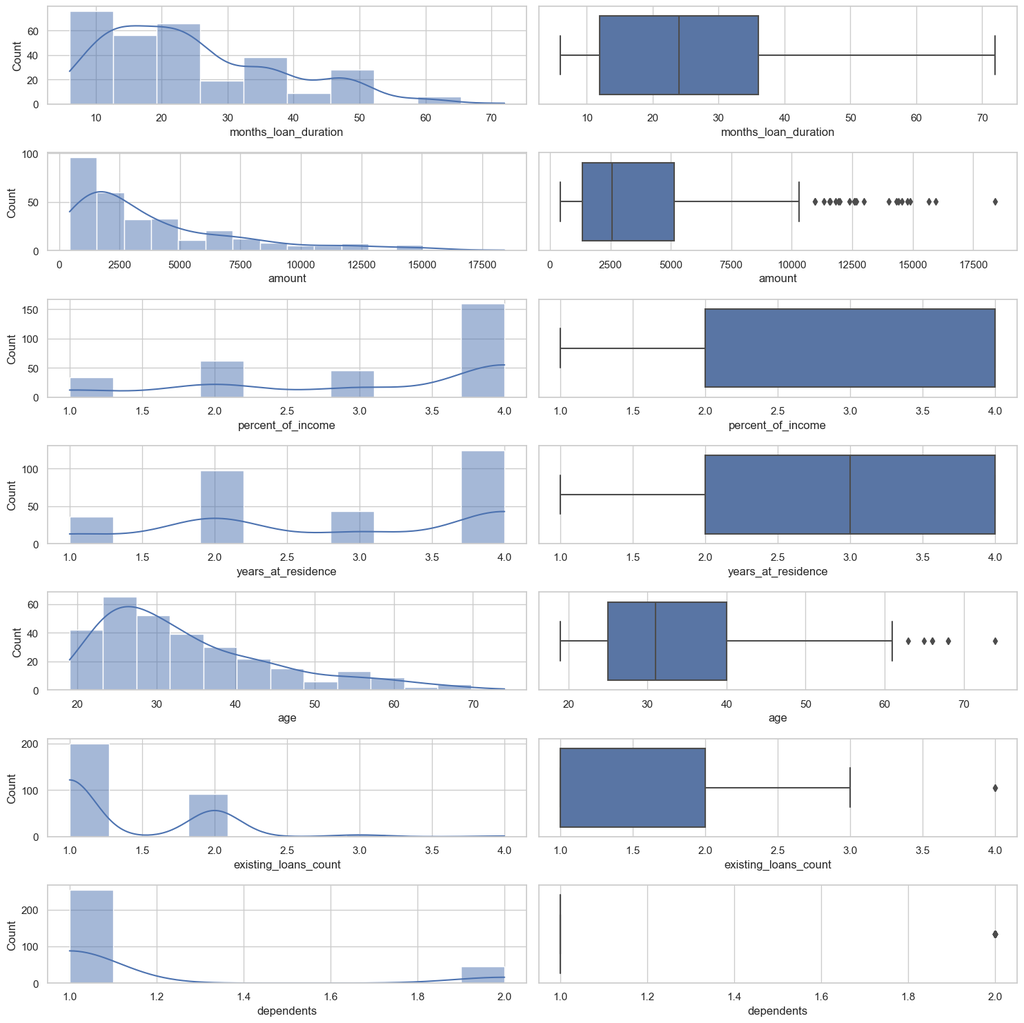

```python
# Plot the distributions of the defaulters based on the numeric columns
fig, axes = plt.subplots(nrows=7,ncols=2, figsize = (15,15))
for index in range(len(num_cols)):
    sns.histplot(defualters_df[num_cols[index]], kde=True, ax=axes[index][0])
    sns.boxplot(x=num_cols[index], data=defualters_df, ax=axes[index][1])
plt.tight_layout()
plt.show()
```

Findings :

- The `months_loan_duration` between 10 to 25 have more defaulters.
- The loan `amount` between approximately 1000 and 5000 have more defaulters.
- The `age` group between 25 to 50 tends to default more.

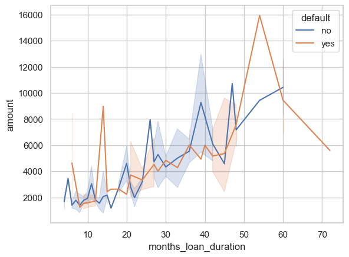

```python
sns.lineplot(x = 'months_loan_duration', y = 'amount', data = df, hue = 'default')
plt.show()
```

Findings :

- As the loan `amount` and `months_loan_duration` increases the defaulters are also increasing.

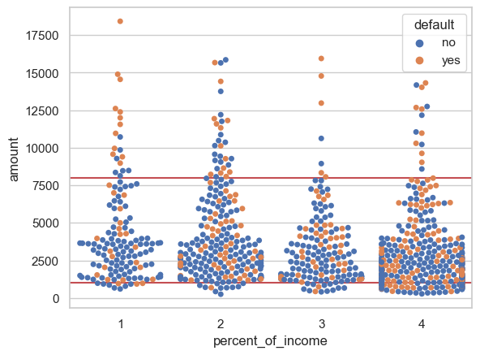

```
percent_of_income  default
1                  no         102
                   yes         34
2                  no         169
                   yes         62
3                  no         112
                   yes         45
4                  no         317
                   yes        159
Name: default, dtype: int64
```

```python
sns.swarmplot(x = 'percent_of_income', y = 'amount', data = df, hue = 'default')
plt.axhline(y=1000, color = 'r')
plt.axhline(y=8000, color = 'r')
plt.show()
df.groupby('percent_of_income')['default'].value_counts()
```

Findings :

- As we can see that there are more defaulters whose `percent_of_income` is 4 and loan `amount` approximately bewteen 1000 and 8000.
- Hence, the bank check this condition while giving loan to the customer.

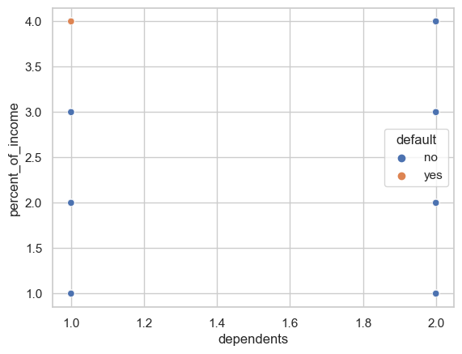

```
percent_of_income = 4, dependents = 1
no     283
yes    132
Name: default, dtype: int64

percent_of_income = 4, dependents = 2
no     34
yes    27
Name: default, dtype: int64

percent_of_income = 2, dependents = 1
no     141
yes     52
Name: default, dtype: int64

percent_of_income = 2, dependents = 2
no     28
yes    10
Name: default, dtype: int64

percent_of_income = 3, dependents = 1
no     89
yes    40
Name: default, dtype: int64

percent_of_income = 3, dependents = 2
no     23
yes     5
Name: default, dtype: int64

percent_of_income = 1, dependents = 1
no     78
yes    30
Name: default, dtype: int64

percent_of_income = 1, dependents = 2
no     24
yes     4
Name: default, dtype: int64
```

```python
# check the relation between percent_of_income and dependents
sns.scatterplot(x = 'dependents', y = 'percent_of_income', data = df, hue = 'default')
plt.show()

percent_of_income = df['percent_of_income'].unique()
dependents = df['dependents'].unique()

for i in percent_of_income:
    for j in dependents:
        print(f"percent_of_income = {i}, dependents = {j}")
        print(df[(df['percent_of_income'] == i) & (df['dependents'] == j)]['default'].value_counts())
        print()
```

Findings :

- As we can see that there are more defaulters whose `percent_of_income` is 4 and `dependents` is 1
- Hence, the bank check this condition while giving loan to the customer.

## Preprocessing the data

#### Apply label encoding on the categorical columns

```python
# Performing label encoding for the categorical variables
label_endcoding_cols = ['checking_balance','credit_history','purpose','savings_balance',
                        'employment_duration','other_credit','housing','job','phone','default']
for col in label_endcoding_cols:
    df[col] = pd.Categorical(df[col]).codes # label encode the columns
df
```

|  | checking_balance | months_loan_duration | credit_history | purpose | amount | savings_balance | employment_duration | percent_of_income | years_at_residence | age | other_credit | housing | existing_loans_count | job | dependents | phone | default |
| --- | --- | --- | --- | --- | --- | --- | --- | --- | --- | --- | --- | --- | --- | --- | --- | --- | --- |
| 0 | 1 | 6 | 0 | 4 | 1169 | 4 | 3 | 4 | 4 | 67 | 1 | 1 | 2 | 1 | 1 | 1 | 0 |
| 1 | 0 | 48 | 1 | 4 | 5951 | 2 | 0 | 2 | 2 | 22 | 1 | 1 | 1 | 1 | 1 | 0 | 1 |
| 2 | 3 | 12 | 0 | 3 | 2096 | 2 | 1 | 2 | 3 | 49 | 1 | 1 | 1 | 3 | 2 | 0 | 0 |
| 3 | 1 | 42 | 1 | 4 | 7882 | 2 | 1 | 2 | 4 | 45 | 1 | 0 | 1 | 1 | 2 | 0 | 0 |
| 4 | 1 | 24 | 3 | 1 | 4870 | 2 | 0 | 3 | 4 | 53 | 1 | 0 | 2 | 1 | 2 | 0 | 1 |
| ... | ... | ... | ... | ... | ... | ... | ... | ... | ... | ... | ... | ... | ... | ... | ... | ... | ... |
| 995 | 3 | 12 | 1 | 4 | 1736 | 2 | 1 | 3 | 4 | 31 | 1 | 1 | 1 | 3 | 1 | 0 | 0 |
| 996 | 1 | 30 | 1 | 1 | 3857 | 2 | 0 | 4 | 4 | 40 | 1 | 1 | 1 | 0 | 1 | 1 | 0 |
| 997 | 3 | 12 | 1 | 4 | 804 | 2 | 3 | 4 | 4 | 38 | 1 | 1 | 1 | 1 | 1 | 0 | 0 |
| 998 | 1 | 45 | 1 | 4 | 1845 | 2 | 0 | 4 | 4 | 23 | 1 | 0 | 1 | 1 | 1 | 1 | 1 |
| 999 | 0 | 45 | 0 | 1 | 4576 | 0 | 4 | 3 | 4 | 27 | 1 | 1 | 1 | 1 | 1 | 0 | 0 |

1000 rows × 17 columns

#### Split the data into training and testing

```python
# Split the data into features(X) and labels(y)
random.seed(10) # set the random seed to split consistently

target_variable = 'default' # set the target variable
random_state = 10 # set the random state
test_size = .20 # set the test size (80:20)

X = df.drop(target_variable, axis = 1) # Features
y = df[[target_variable]] # Labels

X_train, X_test, y_train, y_test = train_test_split(X, y,
                                                    test_size = test_size,
                                                    random_state = random_state,
                                                    stratify=y) # apply stratification to the target column
print("The shapes of training and testing data after the split(80:20) :")
print(f"\nShape of X_train : {X_train.shape}\nShape of X_test : {X_test.shape}")
print(f"Shape of y_train : {y_train.shape}\nShape of y_test : {y_test.shape}")
```

```
The shapes of training and testing data after the split(80:20) :

Shape of X_train : (800, 16)
Shape of X_test : (200, 16)
Shape of y_train : (800, 1)
Shape of y_test : (200, 1)
```

```python
# Checking if the stratification is performed on the target variable
print("\nTraining data proportions :")
print(pd.concat([X_train,y_train])['default'].value_counts(normalize=True))
print("\nTesting data proportions :")
print(pd.concat([X_test,y_test])['default'].value_counts(normalize=True))
```

```
Training data proportions :
0.0    0.7
1.0    0.3
Name: default, dtype: float64

Testing data proportions :
0.0    0.7
1.0    0.3
Name: default, dtype: float64
```

### Build the following base models

- `Logistic Regression`
- `LDA`
- `Random forest`
- `SVM`
- `Gradient Boosting`
- `Xg Boost`

```python
# Create a dictionary to save the base fitted models
base_models = {}
# Create a dictionary to save the grid search fitted models
grid_search_models = {}
# Create a ditionary to save the metrics
model_metrics = {}
```

```python
# Create a general function to fit the models
def fit_model(**kwargs):
    name = kwargs['name']
    print(f"-------------Performing {name}-------------\n")
    print(f"-------------Started {name}-------------\n")
    model = kwargs['model']
    X,y = kwargs['X'],kwargs['y']
    fitted_model = model.fit(X,y)
    print(f"Model : {fitted_model}")
    print()
    print(f"-------------Completed {name}-------------\n")
    return fitted_model
```

```python
# Create a function to plot the precision recall curve
def plot_precision_recall_curve(**kwargs):
    model = kwargs['model']
    X = kwargs['X']
    y = kwargs['y']
    y_scores_model = model.predict_proba(X) # predict_proba gives the probability of each observation belonging to each class
    precisions, recalls, thresholds = precision_recall_curve(y, y_scores_model[:, 1])
    # Plot values of precisions, recalls, and thresholds
    plt.figure(figsize = (7, 7))
    plt.plot(thresholds, precisions[:-1], 'b--', label = 'precision')
    plt.plot(thresholds, recalls[:-1], 'g--', label = 'recall')
    plt.xlabel('Threshold')
    plt.legend(loc = 'upper left')
    plt.ylim([0, 1])
    plt.show()
```

```python
# Create a function to get metrics for actual and predicted values
def metrics_score(actual, predicted):
    print(classification_report(actual, predicted))
    cm = confusion_matrix(actual, predicted)
    plt.figure(figsize = (8, 5))
    sns.heatmap(cm, annot = True, fmt = 'd')
    plt.ylabel('Actual')
    plt.xlabel('Predicted')
    plt.show()
```

```python
# Create a class to validate the model on training and testing data
class Evaluation:
    """
    This class performs the following operations on training and testing data -

        ----> Calculates accuracy, precision, recall, f1-score.
        ----> Prints classification report.
        ----> Prints confusion matrix.
        ----> Calculates Area under curve(AUC)
        ----> Prints the ROC curves
    """
    def __init__(self,**kwargs):
        # Assign the keyword arguments
        self.kwargs = kwargs
        self.model = kwargs['model']
        self.X_train, self.X_test = kwargs['X_train'],kwargs['X_test']
        self.y_train, self.y_test = kwargs['y_train'],kwargs['y_test']
        self.train_metrics,self.test_metrics = {},{}
        self.perform_model_prediction()
        self.accuracy_score()
        self.classification_report()
        self.confusion_matrix()
        self.roc_curve()

    def perform_model_prediction(self):
        # Get the predicted values by the model
        self.y_train_pred = self.model.predict(self.X_train)
        self.y_test_pred = self.model.predict(self.X_test)

        # Get the prediction probabilities by the model
        self.y_train_prob = self.model.predict_proba(self.X_train)
        self.y_test_prob = self.model.predict_proba(self.X_test)

    def metrics(self,report):
        prec = round(report.loc["1"][0]*100,2)
        recall = round(report.loc["1"][1]*100,2)
        f1 = round(report.loc["1"][2]*100,2)
        return prec,recall,f1

    def accuracy_score(self):
        # Get the accuracy score for the model on training and testing data
        train_acc = round(accuracy_score(self.y_train,self.y_train_pred)*100,2)
        test_acc = round(accuracy_score(self.y_test,self.y_test_pred)*100,2)
        self.train_metrics['train_acc'] = train_acc
        self.test_metrics['test_acc'] = test_acc
        print(f"\nThe accuracy score for {self.model} model on training data is {train_acc}%")
        print(f"\nThe accuracy score for {self.model} model on testing data is {test_acc}%")


    def classification_report(self):
        # Get the classification report for the model on training and testing data
        self.train_report_df = pd.DataFrame(classification_report(self.y_train,self.y_train_pred,output_dict=True)).transpose()
        self.test_report_df = pd.DataFrame(classification_report(self.y_test,self.y_test_pred,output_dict=True)).transpose()
        self.train_report = classification_report(self.y_train,self.y_train_pred)
        self.test_report = classification_report(self.y_test,self.y_test_pred)
        print(f"\nThe classification report for {self.model} model on training data is \n\n{self.train_report}")
        print(f"\nThe classification report for {self.model} model on testing data is \n\n{self.test_report}")

        train_temp = self.metrics(self.train_report_df)
        test_temp = self.metrics(self.test_report_df)

        self.train_metrics['train_precision'], self.test_metrics['test_precision'] = train_temp[0],test_temp[0]
        self.train_metrics['train_recall'], self.test_metrics['test_recall'] = train_temp[1], test_temp[1]
        self.train_metrics['train_f1'], self.test_metrics['test_f1'] = train_temp[2], test_temp[2]

    def confusion_matrix(self):
        # Plot the confusion matrix for the model on training and testing data
        sns.heatmap(confusion_matrix(self.y_train,self.y_train_pred) ,annot=True, fmt='d', cbar=False)
        plt.title(f'Confusion Matrix for {self.model} model on training data')
        plt.xlabel('Predicted Label')
        plt.ylabel('Actual Label')
        plt.show()
        sns.heatmap(confusion_matrix(self.y_test,self.y_test_pred) ,annot=True, fmt='d', cbar=False)
        plt.title(f'Confusion Matrix for {self.model} model on testing data')
        plt.xlabel('Predicted Label')
        plt.ylabel('Actual Label')
        plt.show()

    def auc_score(self):
        # Get the AUC score for the model on training and testing data
        train_auc = round(roc_auc_score(self.y_train,self.y_train_prob[:,1])*100,2)
        test_auc = round(roc_auc_score(self.y_test,self.y_test_prob[:,1])*100,2)
        self.train_metrics['train_auc'] = train_auc
        self.test_metrics['test_auc'] = test_auc

    def plot_roc_curve(self,y_true,y_pred_prob):
        fpr, tpr, thresholds = roc_curve(y_true, y_pred_prob[:, 1])
        plt.plot([0, 1], [0, 1], linestyle='--')
        plt.plot(fpr, tpr, marker='.')
        plt.xlabel("FPR(false positive rate)")
        plt.ylabel("TPR(true positive rate)")
        plt.show()

    def roc_curve(self):
        # Plot the ROC curve for the model on training and testing data
        self.auc_score()
        print(f"\nAUC for {self.model} model on training data is {self.train_metrics['train_auc']}")
        print("\nROC curve for training data: ")
        self.plot_roc_curve(self.y_train, self.y_train_prob)
        print(f"\nAUC for {self.model} model on testing data is {self.test_metrics['test_auc']}")
        print("\nROC curve for testing data: ")
        self.plot_roc_curve(self.y_test, self.y_test_prob)
```

### Logistic Regression (base model)

```python
LR = LogisticRegression()
LR_model = fit_model(name = 'Logistic Regression',
                     model = LR,
                     X = X_train,
                     y = y_train)
base_models['LR'] = LR_model
```

```
-------------Performing Logistic Regression-------------

-------------Started Logistic Regression-------------

Model : LogisticRegression()

-------------Completed Logistic Regression-------------
```

```
The accuracy score for LogisticRegression() model on training data is 72.0%

The accuracy score for LogisticRegression() model on testing data is 71.0%

The classification report for LogisticRegression() model on training data is

              precision    recall  f1-score   support

           0       0.75      0.89      0.82       560
           1       0.56      0.32      0.40       240

    accuracy                           0.72       800
   macro avg       0.66      0.60      0.61       800
weighted avg       0.69      0.72      0.69       800


The classification report for LogisticRegression() model on testing data is

              precision    recall  f1-score   support

           0       0.75      0.89      0.81       140
           1       0.53      0.30      0.38        60

    accuracy                           0.71       200
   macro avg       0.64      0.59      0.60       200
weighted avg       0.68      0.71      0.68       200
```

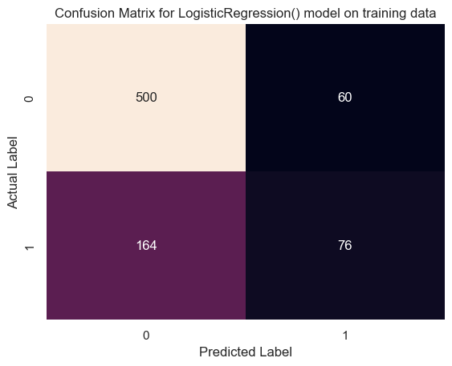

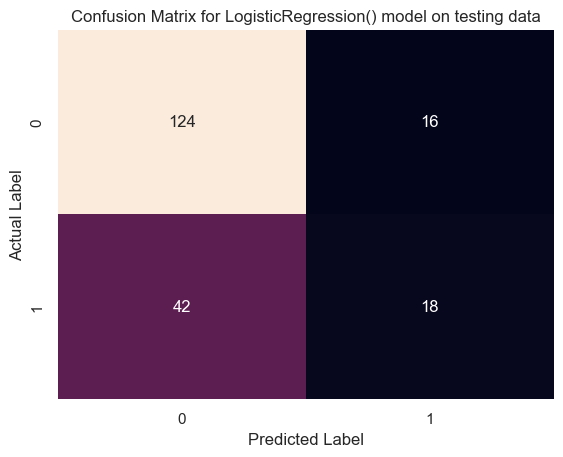

```
AUC for LogisticRegression() model on training data is 75.72

ROC curve for training data:
```

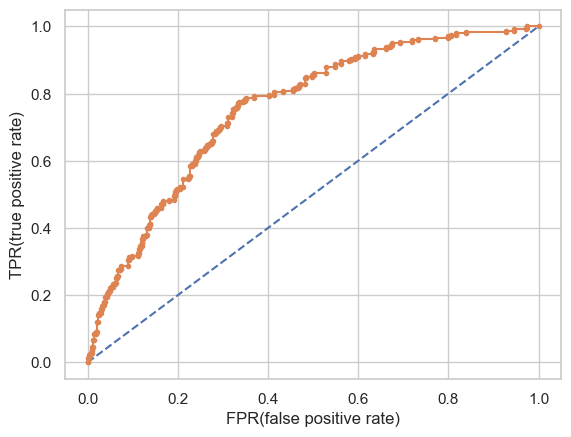

```
AUC for LogisticRegression() model on testing data is 72.95

ROC curve for testing data:
```

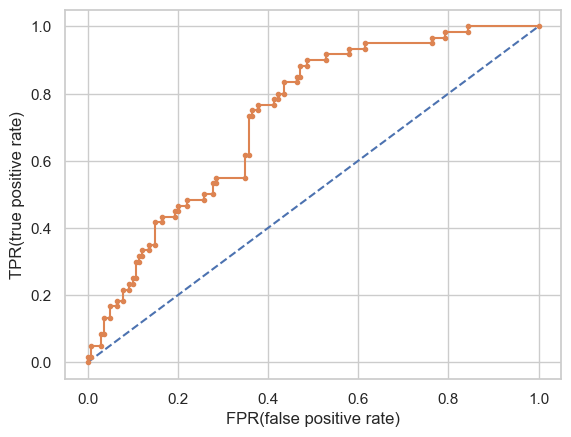

```python
## Validate the logistic regression base model
eval_LR = Evaluation(model = base_models['LR'],
                     X_train = X_train,X_test = X_test,
                     y_train = y_train,y_test = y_test)
model_metrics['LR'] = eval_LR
```

```python
print(f"Training Metrics for LR : \n{eval_LR.train_metrics}")
print()
print(f"Testing Metrics for LR: \n{eval_LR.test_metrics}")
```

```
Training Metrics for LR :
{'train_acc': 72.0, 'train_precision': 55.88, 'train_recall': 31.67, 'train_f1': 40.43, 'train_auc': 75.72}

Testing Metrics for LR:
{'test_acc': 71.0, 'test_precision': 52.94, 'test_recall': 30.0, 'test_f1': 38.3, 'test_auc': 72.95}
```

#### Plot the precision recall curve

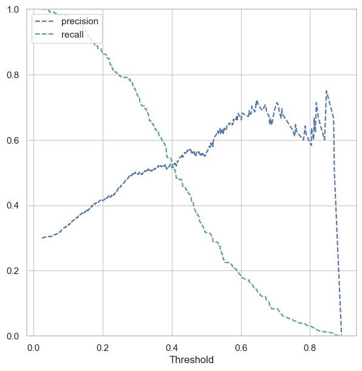

```python
# Plot the precision recall curve to plot the optimal threshold
plot_precision_recall_curve(model = LR_model,
                            X = X_train,
                            y = y_train)
```

- We can identify that the optimal threshold is at 0.4

#### Predict the new values with the threshold of 0.35 for training data and evaluate

```
              precision    recall  f1-score   support

           0       0.83      0.74      0.78       560
           1       0.51      0.64      0.57       240

    accuracy                           0.71       800
   macro avg       0.67      0.69      0.67       800
weighted avg       0.73      0.71      0.72       800
```

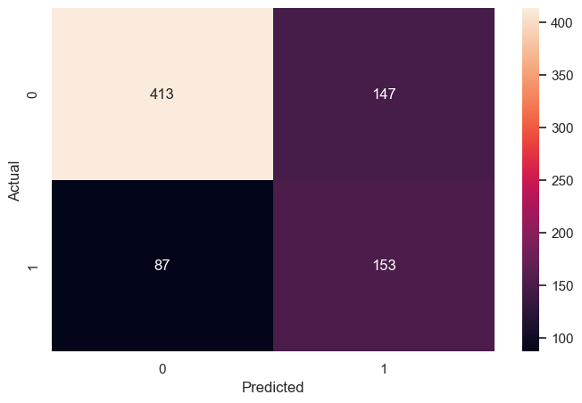

```python
optimal_threshold_lr = 0.35
y_pred_train_LR = eval_LR.y_train_prob
y_pred_train_LR_thr = y_pred_train_LR[:, 1] > optimal_threshold_lr # predicting the values with threshold = 0.35
metrics_score(y_train, y_pred_train_LR_thr)
```

#### Update the train metrics after changing the threshold to 0.35

```python
train_thr_report_LR_df = pd.DataFrame(classification_report(y_train,y_pred_train_LR_thr,output_dict = True)).transpose()
eval_LR.train_metrics['train_acc'] = round(train_thr_report_LR_df.loc["accuracy"][0]*100,2)
eval_LR.train_metrics['train_precision'] = round(train_thr_report_LR_df.loc["1"][0]*100,2)
eval_LR.train_metrics['train_recall'] = round(train_thr_report_LR_df.loc["1"][1]*100,2)
eval_LR.train_metrics['train_f1'] = round(train_thr_report_LR_df.loc["1"][2]*100,2)
eval_LR.train_metrics['train_auc'] = round(roc_auc_score(y_train, y_pred_train_LR_thr)*100,2)
eval_LR.train_metrics
```

```
{'train_acc': 70.75,
 'train_precision': 51.0,
 'train_recall': 63.75,
 'train_f1': 56.67,
 'train_auc': 68.75}
```

#### Predict the new values with the threshold of 0.35 for testing data and evaluate

```
              precision    recall  f1-score   support

           0       0.77      0.73      0.75       140
           1       0.44      0.50      0.47        60

    accuracy                           0.66       200
   macro avg       0.61      0.61      0.61       200
weighted avg       0.67      0.66      0.67       200
```

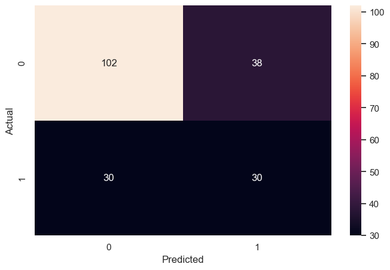

```python
y_pred_test_LR = eval_LR.y_test_prob
y_pred_test_LR_thr = y_pred_test_LR[:, 1] > optimal_threshold_lr # predicting the values with threshold = 0.35
metrics_score(y_test, y_pred_test_LR_thr)
```

#### Update the test metrics after changing the threshold to 0.35

```python
test_thr_report_LR_df = pd.DataFrame(classification_report(y_test,y_pred_test_LR_thr,output_dict = True)).transpose()
eval_LR.test_metrics['test_acc'] = round(test_thr_report_LR_df.loc["accuracy"][0]*100,2)
eval_LR.test_metrics['test_precision'] = round(test_thr_report_LR_df.loc["1"][0]*100,2)
eval_LR.test_metrics['test_recall'] = round(test_thr_report_LR_df.loc["1"][1]*100,2)
eval_LR.test_metrics['test_f1'] = round(test_thr_report_LR_df.loc["1"][2]*100,2)
eval_LR.test_metrics['test_auc'] = round(roc_auc_score(y_test, y_pred_test_LR_thr)*100,2)
eval_LR.test_metrics
```

```
{'test_acc': 66.0,
 'test_precision': 44.12,
 'test_recall': 50.0,
 'test_f1': 46.88,
 'test_auc': 61.43}
```

```python
# Final updation of metrics for LR
model_metrics['LR'] = eval_LR
```

### Linear Discriminant Analysis (LDA base model)

```python
LDA = LinearDiscriminantAnalysis()
LDA_model = fit_model(name = 'Linear Discriminant Analysis',
                     model = LDA,
                     X = X_train,
                     y = y_train)
base_models['LDA'] = LDA_model
```

```
-------------Performing Linear Discriminant Analysis-------------

-------------Started Linear Discriminant Analysis-------------

Model : LinearDiscriminantAnalysis()

-------------Completed Linear Discriminant Analysis-------------
```

```
The accuracy score for LinearDiscriminantAnalysis() model on training data is 73.25%

The accuracy score for LinearDiscriminantAnalysis() model on testing data is 72.0%

The classification report for LinearDiscriminantAnalysis() model on training data is

              precision    recall  f1-score   support

           0       0.76      0.91      0.83       560
           1       0.60      0.33      0.42       240

    accuracy                           0.73       800
   macro avg       0.68      0.62      0.62       800
weighted avg       0.71      0.73      0.70       800


The classification report for LinearDiscriminantAnalysis() model on testing data is

              precision    recall  f1-score   support

           0       0.76      0.89      0.82       140
           1       0.56      0.33      0.42        60

    accuracy                           0.72       200
   macro avg       0.66      0.61      0.62       200
weighted avg       0.70      0.72      0.70       200
```

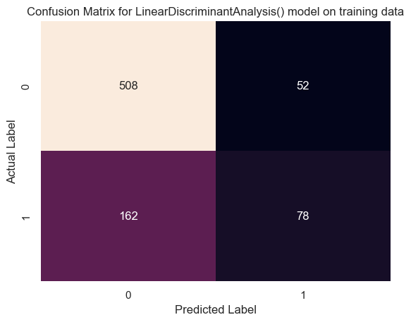

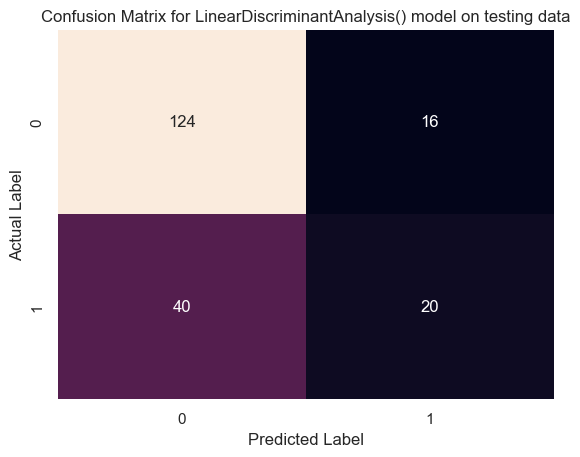

```
AUC for LinearDiscriminantAnalysis() model on training data is 76.22

ROC curve for training data:
```

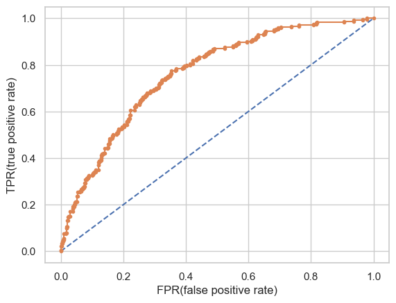

```
AUC for LinearDiscriminantAnalysis() model on testing data is 72.8

ROC curve for testing data:
```

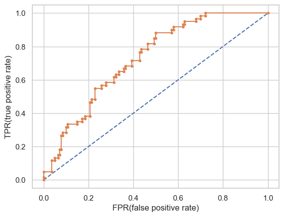

```python
## Validate the linear discriminant analysis base model
eval_LDA = Evaluation(model = base_models['LDA'],
                      X_train = X_train,X_test = X_test,
                      y_train = y_train,y_test = y_test)
model_metrics['LDA'] = eval_LDA
```

```python
print(f"Training Metrics for LDA : \n{eval_LDA.train_metrics}")
print()
print(f"Testing Metrics for LDA: \n{eval_LDA.test_metrics}")
```

```
Training Metrics for LDA :
{'train_acc': 73.25, 'train_precision': 60.0, 'train_recall': 32.5, 'train_f1': 42.16, 'train_auc': 76.22}

Testing Metrics for LDA:
{'test_acc': 72.0, 'test_precision': 55.56, 'test_recall': 33.33, 'test_f1': 41.67, 'test_auc': 72.8}
```

#### Plot the precision recall curve

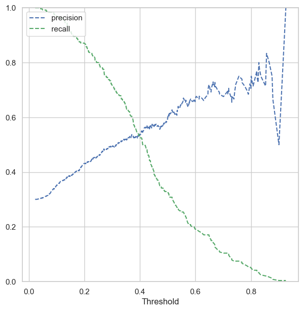

```python
# Plot the precision recall curve to plot the optimal threshold
plot_precision_recall_curve(model = LDA_model,
                            X = X_train,
                            y = y_train)
```

- We can identify that the optimal threshold is at 0.4

#### Predict the new values with the threshold of 0.35 for training data and evaluate

```
              precision    recall  f1-score   support

           0       0.83      0.75      0.78       560
           1       0.52      0.64      0.57       240

    accuracy                           0.71       800
   macro avg       0.67      0.69      0.68       800
weighted avg       0.73      0.71      0.72       800
```

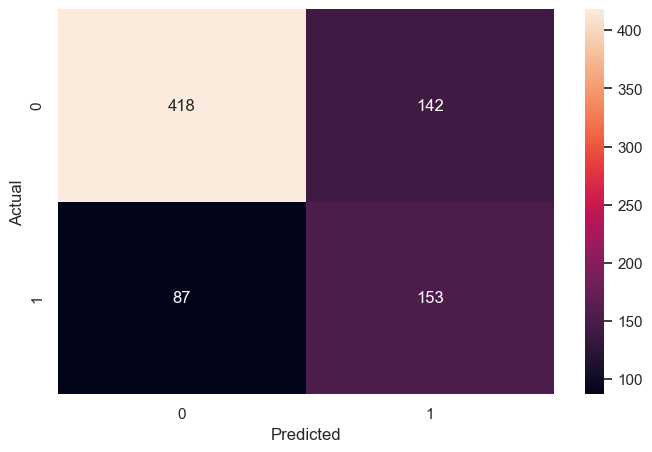

```python
optimal_threshold_lda = 0.35
y_pred_train_LDA = eval_LDA.y_train_prob
y_pred_train_LDA_thr = y_pred_train_LDA[:, 1] > optimal_threshold_lda # predicting the values with threshold = 0.4
metrics_score(y_train, y_pred_train_LDA_thr)
```

#### Update the train metrics after changing the threshold to 0.35

```python
train_thr_report_LDA_df = pd.DataFrame(classification_report(y_train,y_pred_train_LDA_thr,output_dict = True)).transpose()
eval_LDA.train_metrics['train_acc'] = round(train_thr_report_LDA_df.loc["accuracy"][0]*100,2)
eval_LDA.train_metrics['train_precision'] = round(train_thr_report_LDA_df.loc["1"][0]*100,2)
eval_LDA.train_metrics['train_recall'] = round(train_thr_report_LDA_df.loc["1"][1]*100,2)
eval_LDA.train_metrics['train_f1'] = round(train_thr_report_LDA_df.loc["1"][2]*100,2)
eval_LDA.train_metrics['train_auc'] = round(roc_auc_score(y_train, y_pred_train_LDA_thr)*100,2)
eval_LDA.train_metrics
```

```
{'train_acc': 71.38,
 'train_precision': 51.86,
 'train_recall': 63.75,
 'train_f1': 57.2,
 'train_auc': 69.2}
```

#### Predict the new values with the threshold of 0.35 for testing data and evaluate

```
              precision    recall  f1-score   support

           0       0.79      0.74      0.77       140
           1       0.48      0.55      0.51        60

    accuracy                           0.69       200
   macro avg       0.64      0.65      0.64       200
weighted avg       0.70      0.69      0.69       200
```

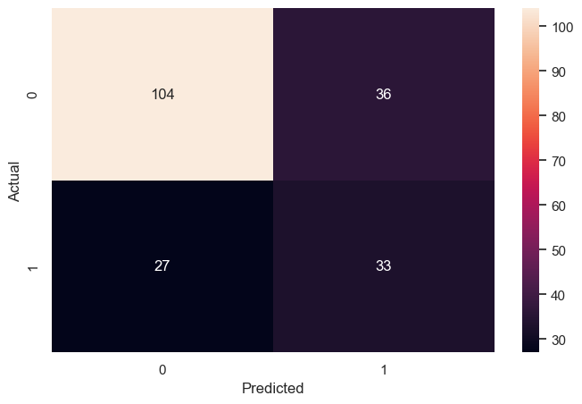

```python
optimal_threshold_lda = 0.35
y_pred_test_LDA = eval_LDA.y_test_prob
y_pred_test_LDA_thr = y_pred_test_LDA[:, 1] > optimal_threshold_lda # predicting the values with threshold = 0.35
metrics_score(y_test, y_pred_test_LDA_thr)
```

#### Update the test metrics after changing the threshold to 0.35

```python
test_thr_report_LDA_df = pd.DataFrame(classification_report(y_test,y_pred_test_LDA_thr,output_dict = True)).transpose()
eval_LDA.test_metrics['test_acc'] = round(test_thr_report_LDA_df.loc["accuracy"][0]*100,2)
eval_LDA.test_metrics['test_precision'] = round(test_thr_report_LDA_df.loc["1"][0]*100,2)
eval_LDA.test_metrics['test_recall'] = round(test_thr_report_LDA_df.loc["1"][1]*100,2)
eval_LDA.test_metrics['test_f1'] = round(test_thr_report_LDA_df.loc["1"][2]*100,2)
eval_LDA.test_metrics['test_auc'] = round(roc_auc_score(y_test, y_pred_test_LDA_thr)*100,2)
eval_LDA.test_metrics
```

```
{'test_acc': 68.5,
 'test_precision': 47.83,
 'test_recall': 55.0,
 'test_f1': 51.16,
 'test_auc': 64.64}
```

```python
# Final updation of metrics for LDA
model_metrics['LDA'] = eval_LDA
```

### Random Forest (Base Model)

```python
RF = RandomForestClassifier(random_state=0)
RF_model = fit_model(name = 'Random Forest',
                     model = RF,
                     X = X_train,
                     y = y_train)
base_models['RF'] = RF_model
print(f"\nThe training score : {RF_model.score(X_train,y_train)}")
print(f"\nThe testing score : {RF_model.score(X_test,y_test)}")
```

```
-------------Performing Random Forest-------------

-------------Started Random Forest-------------

Model : RandomForestClassifier(random_state=0)

-------------Completed Random Forest-------------


The training score : 1.0

The testing score : 0.77
```

- We can see the model is overfitting on the training data. Hence, we need to perform pruning on the tree.

### Random Forest (Pruned)

- Tuning the hyperparameters such as
  - `n_estimators` - The number of trees in the forest.
  - `max_depth` - The maximum depth of the tree.
  - `min_samples_split` - The minimum number of samples required to split an internal node
  - `min_samples_leaf` - The minimum number of samples required to be at a leaf node
  - `max_features` - The number of features to consider when looking for the best split

```python
### Randomnly assigning some values to the above hyper parameters
RF = RandomForestClassifier(n_estimators=150,
                            max_depth = 5,
                            min_samples_split = 5,
                            min_samples_leaf = 5,
                            random_state=0
                            )

RF_pruned_model = fit_model(name = 'Random Forest',
                            model = RF,
                            X = X_train,
                            y = y_train)
base_models['RF_pruned'] = RF_pruned_model
print(f"\nThe training score : {RF_pruned_model.score(X_train,y_train)}")
print(f"\nThe testing score : {RF_pruned_model.score(X_test,y_test)}")
```

```
-------------Performing Random Forest-------------

-------------Started Random Forest-------------

Model : RandomForestClassifier(max_depth=5, min_samples_leaf=5, min_samples_split=5,
                       n_estimators=150, random_state=0)

-------------Completed Random Forest-------------


The training score : 0.7825

The testing score : 0.74
```

- As we can see by performing pruning, we have reduced the overfitting of the model and also the pruned random forest model is performing good on both training and testing datasets.
- Furthermore in order to improve the model performance, we can perform GridSearch Cross-Validation.

#### Feature importances (RF pruned model)

- Analysing the feature importances

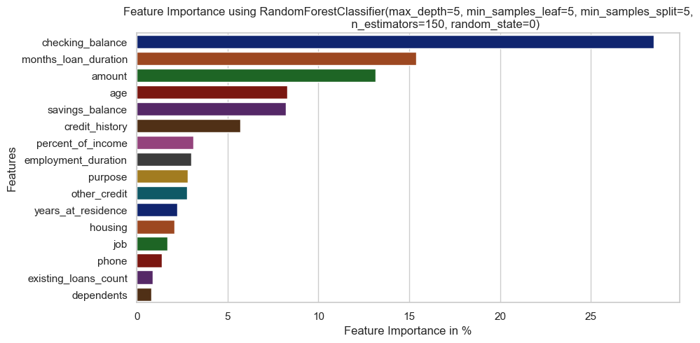

```python
x = pd.DataFrame(RF_pruned_model.feature_importances_*100,index=X_train.columns).sort_values(by=0,ascending=False)
plt.figure(figsize=(10,5))
sns.barplot(data = x, x = x[0],y = x.index,palette='dark')
plt.xlabel('Feature Importance in %')
plt.ylabel('Features')
plt.title(f'Feature Importance using {RF_pruned_model}')
plt.show()
```

```python
x
```

|  | 0 |
| --- | --- |
| checking_balance | 28.463521 |
| months_loan_duration | 15.393599 |
| amount | 13.147139 |
| age | 8.294588 |
| savings_balance | 8.199365 |
| credit_history | 5.690129 |
| percent_of_income | 3.133719 |
| employment_duration | 2.992949 |
| purpose | 2.807279 |
| other_credit | 2.777085 |
| years_at_residence | 2.220668 |
| housing | 2.088199 |
| job | 1.698107 |
| phone | 1.385431 |
| existing_loans_count | 0.894346 |
| dependents | 0.813876 |

Findings -

- According to the model -
  - most important features are `checking_balance`, `months_loan_duration`, `amount`.
  - moderately important features are `age`, `savings_balance`, `credit_history`, `percent_of_income`.
  - the remining features are less important.

#### Build the same RF pruned model on the selected important features

```python
important_cols = x[x[0]>=3].index.tolist() # selecting the features that are greater than or equal to %
RF_pruned_model_selected = fit_model(name = 'Random Forest Pruned with selected columns',
                                     model = RF_pruned_model,
                                     X = X_train[important_cols],
                                     y = y_train)
base_models['RF_pruned_selected'] = RF_pruned_model_selected
print(f"\nThe training score : {RF_pruned_model_selected.score(X_train[important_cols],y_train)}")
print(f"\nThe testing score : {RF_pruned_model_selected.score(X_test[important_cols],y_test)}")
```

```
-------------Performing Random Forest Pruned with selected columns-------------

-------------Started Random Forest Pruned with selected columns-------------

Model : RandomForestClassifier(max_depth=5, min_samples_leaf=5, min_samples_split=5,
                       n_estimators=150, random_state=0)

-------------Completed Random Forest Pruned with selected columns-------------


The training score : 0.79

The testing score : 0.77
```

#### As we can see by selecting the best features the models performance improved a bit from the previous RF pruned model. We can obeserve this by checking the test scores of both the models

- RF pruned model test score - 0.74
- RF pruned model with selected columns test score - 0.77

Though there is no significant amount of improvement, but we were able produce the same kind of results and also eliminated not important features which helps the model to fit faster as well as save memory which when the input size increases.

### Random Forest (Grid Search)

- In order to improve the model performance we perform `GridSearchCV`

```python
# Create a function to compare the current and best model till now
def current_vs_best_model(grid_search_models, X_train,y_train,X_test,y_test, name):
    if  f"{name}_best_model" not in grid_search_models.keys():
        print(f"Perfoming {name} first time.")
        grid_search_models[f'{name}_best_model'] = grid_search_models[f'{name}_current_model']
        best_train_score = grid_search_models[f'{name}_best_model'].score(X_train,y_train)
        best_test_score = grid_search_models[f'{name}_best_model'].score(X_test,y_test)
        print(f"\nBest Train score : {best_train_score}, Test score : {best_test_score}")

    else:
        curr_train_score = grid_search_models[f'{name}_current_model'].score(X_train,y_train)
        curr_test_score = grid_search_models[f'{name}_current_model'].score(X_test,y_test)
        best_train_score = grid_search_models[f'{name}_best_model'].score(X_train,y_train)
        best_test_score = grid_search_models[f'{name}_best_model'].score(X_test,y_test)
        print(f"\nBest Train score : {best_train_score}, Test score : {best_test_score}")
        print(f"\nCurrent Train score : {curr_train_score}, Test score : {curr_test_score}")
        if curr_test_score > best_test_score :
            print(f"\nThere is an improvement of {((curr_train_score-best_train_score)/(best_train_score))*100:.2f} % in training and {((curr_test_score-best_test_score)/(best_test_score))*100:.2f} % in testing datasets")
            grid_search_models[f'{name}_best_model'] = grid_search_models[f'{name}_current_model']
        else:
            print("\nNo improvement found in the scores!!")
    print(f"\nBest {name} model till now : {grid_search_models[f'{name}_best_model']}")
```

```python
# Setting the parameters that needs to perform and performing K-fold cross validation (K=10)
rf_grid_params = {
    'n_estimators' : [100,200,300],
    'max_depth' : [4,6,8],
    'min_samples_split' : [3,5],
    #'min_samples_leaf' : [5],
    #'criterion' : ['gini'],
    'max_features' : [None],
}

RF_grid_search = GridSearchCV(estimator= RandomForestClassifier(random_state=0),
                              param_grid=rf_grid_params,
                              cv=10) # 10-Fold Cross validation
name = 'RF'
selected_cols = important_cols[:6] # selecting the top 6 important columns
RF_grid_model = RF_grid_search.fit(X_train[selected_cols],y_train)

grid_search_models[f'{name}_current_model'] = RF_grid_model.best_estimator_

current_vs_best_model(grid_search_models, X_train[selected_cols],y_train,X_test[selected_cols],y_test, name = name)
```

```
Best Train score : 0.90125, Test score : 0.775

Current Train score : 0.9, Test score : 0.785

There is an improvement of -0.14 % in training and 1.29 % in testing datasets

Best RF model till now : RandomForestClassifier(max_depth=8, max_features=None, min_samples_split=5,
                       n_estimators=300, random_state=0)
```

```
The accuracy score for RandomForestClassifier(max_depth=8, max_features=None, min_samples_split=5,
                       n_estimators=300, random_state=0) model on training data is 90.0%

The accuracy score for RandomForestClassifier(max_depth=8, max_features=None, min_samples_split=5,
                       n_estimators=300, random_state=0) model on testing data is 78.5%

The classification report for RandomForestClassifier(max_depth=8, max_features=None, min_samples_split=5,
                       n_estimators=300, random_state=0) model on training data is

              precision    recall  f1-score   support

           0       0.89      0.97      0.93       560
           1       0.92      0.73      0.81       240

    accuracy                           0.90       800
   macro avg       0.91      0.85      0.87       800
weighted avg       0.90      0.90      0.90       800


The classification report for RandomForestClassifier(max_depth=8, max_features=None, min_samples_split=5,
                       n_estimators=300, random_state=0) model on testing data is

              precision    recall  f1-score   support

           0       0.79      0.94      0.86       140
           1       0.74      0.43      0.55        60

    accuracy                           0.79       200
   macro avg       0.77      0.68      0.70       200
weighted avg       0.78      0.79      0.77       200
```

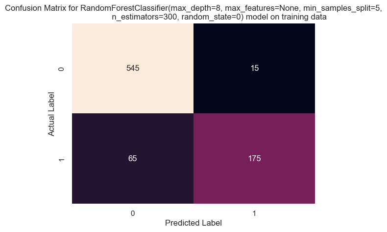

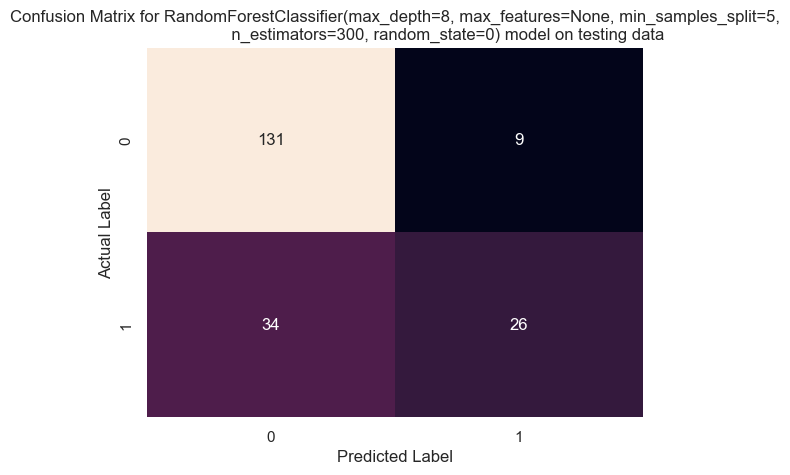

```
AUC for RandomForestClassifier(max_depth=8, max_features=None, min_samples_split=5,
                       n_estimators=300, random_state=0) model on training data is 96.71

ROC curve for training data:
```

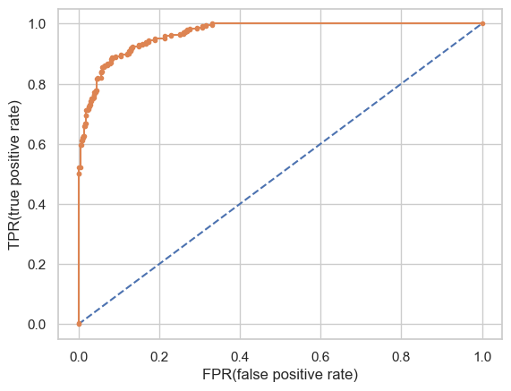

```
AUC for RandomForestClassifier(max_depth=8, max_features=None, min_samples_split=5,
                       n_estimators=300, random_state=0) model on testing data is 77.48

ROC curve for testing data:
```

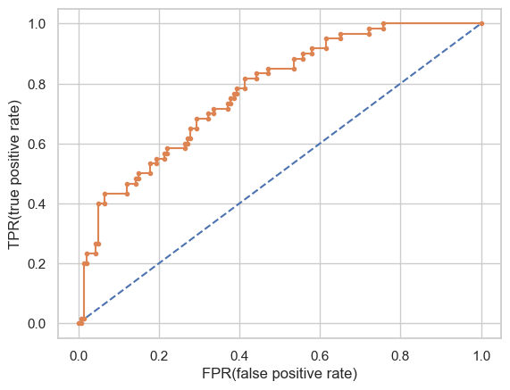

```python
## Validate the Random forest best model achieved using GridSearchCv
eval_RF_Grid = Evaluation(model = grid_search_models['RF_best_model'],
                          X_train = X_train[selected_cols],X_test = X_test[selected_cols],
                          y_train = y_train,y_test = y_test)
model_metrics['RF_Grid'] = eval_RF_Grid
```

### Support Vector Machine (SVM)

```python
svm = SVC(random_state=0,probability = True)
svm_model = fit_model(name = 'Support Vector Machine',
                     model = svm,
                     X = X_train,
                     y = y_train)
base_models['svm'] = svm_model
print(f"\nThe training score : {svm_model.score(X_train,y_train)}")
print(f"\nThe testing score : {svm_model.score(X_test,y_test)}")
```

```
-------------Performing Support Vector Machine-------------

-------------Started Support Vector Machine-------------

Model : SVC(probability=True, random_state=0)

-------------Completed Support Vector Machine-------------


The training score : 0.71

The testing score : 0.7
```

```
The accuracy score for SVC(probability=True, random_state=0) model on training data is 71.0%

The accuracy score for SVC(probability=True, random_state=0) model on testing data is 70.0%

The classification report for SVC(probability=True, random_state=0) model on training data is

              precision    recall  f1-score   support

           0       0.71      0.99      0.83       560
           1       0.72      0.05      0.10       240

    accuracy                           0.71       800
   macro avg       0.72      0.52      0.46       800
weighted avg       0.71      0.71      0.61       800


The classification report for SVC(probability=True, random_state=0) model on testing data is

              precision    recall  f1-score   support

           0       0.70      0.99      0.82       140
           1       0.50      0.03      0.06        60

    accuracy                           0.70       200
   macro avg       0.60      0.51      0.44       200
weighted avg       0.64      0.70      0.59       200
```

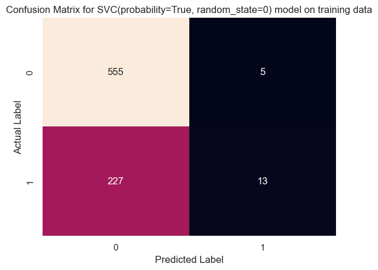

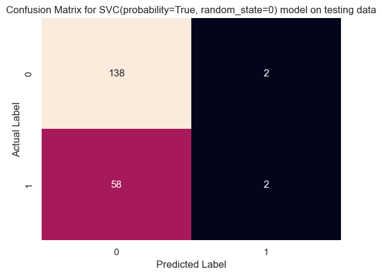

```
AUC for SVC(probability=True, random_state=0) model on training data is 54.87

ROC curve for training data:
```

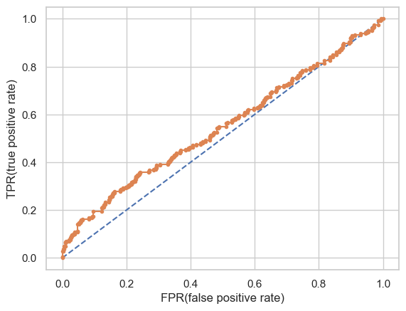

```
AUC for SVC(probability=True, random_state=0) model on testing data is 52.27

ROC curve for testing data:
```

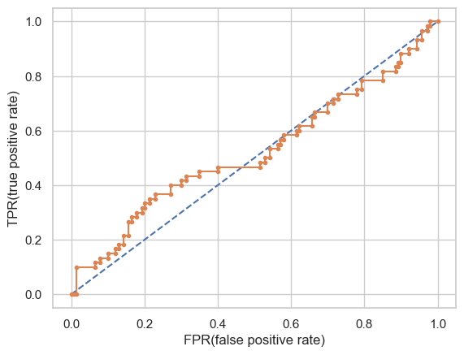

```python
## Validate the SVM model
eval_SVM_Grid = Evaluation(model = base_models['svm'],
                          X_train = X_train,X_test = X_test,
                          y_train = y_train,y_test = y_test)
model_metrics['SVM_Grid'] = eval_SVM_Grid
```

### Gradient Boosting

```python
### Adding the hyperparameters that gave best results with Random forest Gridsearch
GB = GradientBoostingClassifier(n_estimators=300,
                                max_depth = 8,
                                min_samples_split = 5,
                                random_state=0,
                                max_features=None,
                                learning_rate=0.3
                                )

GB_model = fit_model(name = 'Gradient Boosting',
                     model = GB,
                     X = X_train[selected_cols], # fit on the selected columns
                     y = y_train)
base_models['GB'] = GB_model
print(f"\nThe training score : {GB_model.score(X_train[selected_cols],y_train)}")
print(f"\nThe testing score : {GB_model.score(X_test[selected_cols],y_test)}")
```

```
-------------Performing Gradient Boosting-------------

-------------Started Gradient Boosting-------------

Model : GradientBoostingClassifier(learning_rate=0.3, max_depth=8, min_samples_split=5,
                           n_estimators=300, random_state=0)

-------------Completed Gradient Boosting-------------


The training score : 1.0

The testing score : 0.75
```